# FitBit

Abir

24/02/2022

## ASK PHASE

**Buisness Task**

- Analyze Fitbit user data to understand how consumers are using their tracker.
- Provide recommendations for the Bellabeat marketing team.

## PREPARE

**About the data**

This dataset was downloaded from Kaggle.

**Credibility of data**

```r
library(tidyverse)
```

```r
library(dplyr)
library(ggplot2)
library(skimr)
library(janitor)
```

**Loading and naming the data that we are going to work**

```r
setwd("C:/Users/HP/Desktop/Notes/DATA ANALYST/Project/Bellabeat/archive/Fitabase Data")
daily_activity <- read.csv("dailyActivity_merged.csv")
weight_log <- read.csv("weightLogInfo_merged.csv")
sleep_log <- read.csv("sleepDay_merged.csv")
```

## PROCESS

```r
colnames(daily_activity)
```

```
##  [1] "Id"                       "ActivityDate"
##  [3] "TotalSteps"               "TotalDistance"
##  [5] "TrackerDistance"          "LoggedActivitiesDistance"
##  [7] "VeryActiveDistance"       "ModeratelyActiveDistance"
##  [9] "LightActiveDistance"      "SedentaryActiveDistance"
## [11] "VeryActiveMinutes"        "FairlyActiveMinutes"
## [13] "LightlyActiveMinutes"     "SedentaryMinutes"
## [15] "Calories"
```

```r
colnames(weight_log)
```

```
## [1] "Id"             "Date"           "WeightKg"       "WeightPounds"
## [5] "Fat"            "BMI"            "IsManualReport" "LogId"
```

```r
colnames(sleep_log)
```

```
## [1] "Id"                 "SleepDay"           "TotalSleepRecords"
## [4] "TotalMinutesAsleep" "TotalTimeInBed"
```

```r
head(daily_activity)
```

```
##           Id ActivityDate TotalSteps TotalDistance TrackerDistance
## 1 1503960366    4/12/2016      13162          8.50            8.50
## 2 1503960366    4/13/2016      10735          6.97            6.97
## 3 1503960366    4/14/2016      10460          6.74            6.74
## 4 1503960366    4/15/2016       9762          6.28            6.28
## 5 1503960366    4/16/2016      12669          8.16            8.16
## 6 1503960366    4/17/2016       9705          6.48            6.48
##   LoggedActivitiesDistance VeryActiveDistance ModeratelyActiveDistance
## 1                        0               1.88                     0.55
## 2                        0               1.57                     0.69
## 3                        0               2.44                     0.40
## 4                        0               2.14                     1.26
## 5                        0               2.71                     0.41
## 6                        0               3.19                     0.78
##   LightActiveDistance SedentaryActiveDistance VeryActiveMinutes
## 1                6.06                       0                25
## 2                4.71                       0                21
## 3                3.91                       0                30
## 4                2.83                       0                29
## 5                5.04                       0                36
## 6                2.51                       0                38
##   FairlyActiveMinutes LightlyActiveMinutes SedentaryMinutes Calories
## 1                  13                  328              728     1985
## 2                  19                  217              776     1797
## 3                  11                  181             1218     1776
## 4                  34                  209              726     1745
## 5                  10                  221              773     1863
## 6                  20                  164              539     1728
```

```r
head(weight_log)
```

```
##           Id                  Date WeightKg WeightPounds Fat   BMI
## 1 1503960366  5/2/2016 11:59:59 PM     52.6     115.9631  22 22.65
## 2 1503960366  5/3/2016 11:59:59 PM     52.6     115.9631  NA 22.65
## 3 1927972279  4/13/2016 1:08:52 AM    133.5     294.3171  NA 47.54
## 4 2873212765 4/21/2016 11:59:59 PM     56.7     125.0021  NA 21.45
## 5 2873212765 5/12/2016 11:59:59 PM     57.3     126.3249  NA 21.69
## 6 4319703577 4/17/2016 11:59:59 PM     72.4     159.6147  25 27.45
##   IsManualReport        LogId
## 1           True 1.462234e+12
## 2           True 1.462320e+12
## 3          False 1.460510e+12
## 4           True 1.461283e+12
## 5           True 1.463098e+12
## 6           True 1.460938e+12
```

```r
head(sleep_log)
```

```
##           Id              SleepDay TotalSleepRecords TotalMinutesAsleep
## 1 1503960366 4/12/2016 12:00:00 AM                 1                327
## 2 1503960366 4/13/2016 12:00:00 AM                 2                384
## 3 1503960366 4/15/2016 12:00:00 AM                 1                412
## 4 1503960366 4/16/2016 12:00:00 AM                 2                340
## 5 1503960366 4/17/2016 12:00:00 AM                 1                700
## 6 1503960366 4/19/2016 12:00:00 AM                 1                304
##   TotalTimeInBed
## 1            346
## 2            407
## 3            442
## 4            367
## 5            712
## 6            320
```

Counting of how many distinct values are in the datasets’ ID columns

```r
n_distinct(daily_activity$Id)
```

```
## [1] 33
```

```r
n_distinct(weight_log$Id)
```

```
## [1] 8
```

```r
n_distinct(sleep_log$Id)
```

```
## [1] 24
```

```r
nrow(daily_activity)
```

```
## [1] 940
```

```r
nrow(weight_log)
```

```
## [1] 67
```

```r
nrow(sleep_log)
```

```
## [1] 413
```

Now,

```r
nrow(daily_activity[duplicated(daily_activity),])
```

```
## [1] 0
```

```r
nrow(weight_log[duplicated(weight_log),])
```

```
## [1] 0
```

```r
nrow(sleep_log[duplicated(sleep_log),])
```

```
## [1] 3
```

There are 3 duplicates in sleep_log dataframe. So we create new sleep_log_new data frame without any duplicates

```r
sleep_log_new <- unique(sleep_log)
```

Now, checking sleep_log_new for duplicates

```r
nrow(sleep_log_new[duplicated(sleep_log_new),])
```

```
## [1] 0
```

```r
nrow(sleep_log_new)
```

```
## [1] 410
```

## Analyze

Now that the data is loaded and clean, let’s look at the data’s summary statistics

```r
daily_activity %>%
  select(TotalSteps,
         TotalDistance,
         FairlyActiveMinutes,
         VeryActiveDistance,
         SedentaryMinutes,
         Calories) %>%
  summary()
```

```
##    TotalSteps    TotalDistance    FairlyActiveMinutes VeryActiveDistance
##  Min.   :    0   Min.   : 0.000   Min.   :  0.00      Min.   : 0.000
##  1st Qu.: 3790   1st Qu.: 2.620   1st Qu.:  0.00      1st Qu.: 0.000
##  Median : 7406   Median : 5.245   Median :  6.00      Median : 0.210
##  Mean   : 7638   Mean   : 5.490   Mean   : 13.56      Mean   : 1.503
##  3rd Qu.:10727   3rd Qu.: 7.713   3rd Qu.: 19.00      3rd Qu.: 2.053
##  Max.   :36019   Max.   :28.030   Max.   :143.00      Max.   :21.920
##  SedentaryMinutes    Calories
##  Min.   :   0.0   Min.   :   0
##  1st Qu.: 729.8   1st Qu.:1828
##  Median :1057.5   Median :2134
##  Mean   : 991.2   Mean   :2304
##  3rd Qu.:1229.5   3rd Qu.:2793
##  Max.   :1440.0   Max.   :4900
```

```r
sleep_log_new %>%
  select(TotalSleepRecords,
         TotalMinutesAsleep,
         TotalTimeInBed)%>%
  summary()
```

```
##  TotalSleepRecords TotalMinutesAsleep TotalTimeInBed
##  Min.   :1.00      Min.   : 58.0      Min.   : 61.0
##  1st Qu.:1.00      1st Qu.:361.0      1st Qu.:403.8
##  Median :1.00      Median :432.5      Median :463.0
##  Mean   :1.12      Mean   :419.2      Mean   :458.5
##  3rd Qu.:1.00      3rd Qu.:490.0      3rd Qu.:526.0
##  Max.   :3.00      Max.   :796.0      Max.   :961.0
```

```r
weight_log %>%
  select(WeightPounds,
         BMI)%>%
  summary()
```

```
##   WeightPounds        BMI
##  Min.   :116.0   Min.   :21.45
##  1st Qu.:135.4   1st Qu.:23.96
##  Median :137.8   Median :24.39
##  Mean   :158.8   Mean   :25.19
##  3rd Qu.:187.5   3rd Qu.:25.56
##  Max.   :294.3   Max.   :47.54
```

**Observations of analysis**

daily_activity:

sleep_log_new:

- Users slept on average of 419.2 minnutes, or around 7 hors.
- Users time asleep and time in bed was fairly similar.

weight_log:

- The data in weight_log in very less.
- Users are not entering their data into the app.

## Visualizations

**Relationships between Total Steps and Sedentary Minutes**

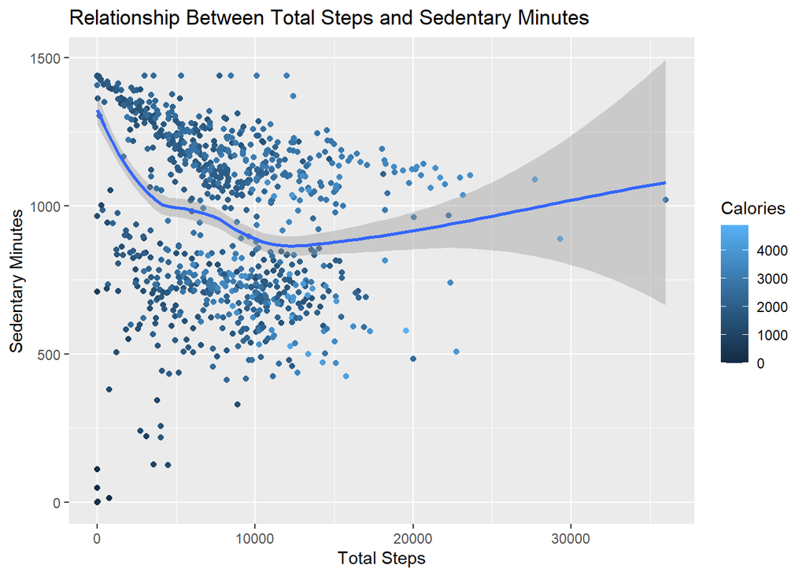

```r
ggplot(data=daily_activity)+
  geom_point(mapping = aes(x=TotalSteps, y=SedentaryMinutes, color = Calories))+
  geom_smooth(mapping = aes(x=TotalSteps, y=SedentaryMinutes))+
  labs(title="Relationship Between Total Steps and Sedentary Minutes", x="Total Steps",y="Sedentary Minutes")
```

**Relationship between total minutes asleep and total times in bed**

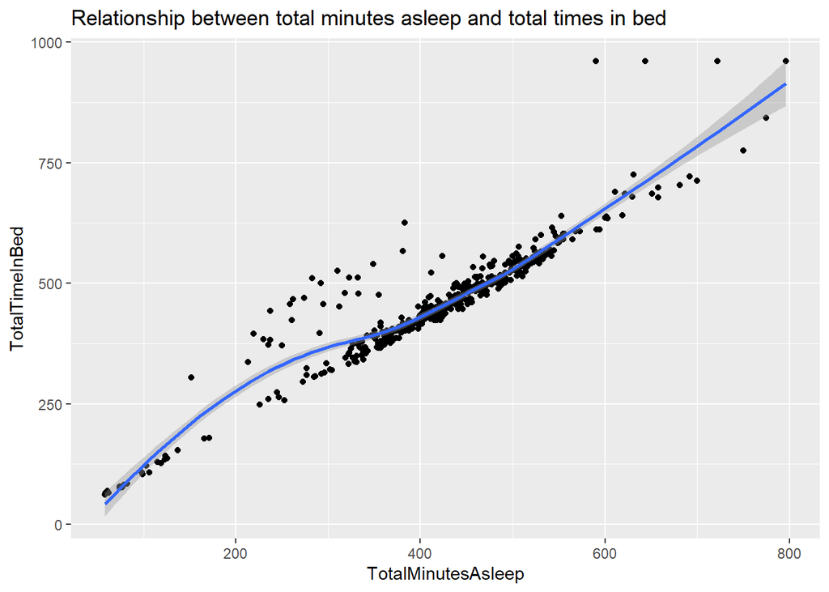

```r
ggplot(data=sleep_log_new)+
  geom_point(mapping=aes(x=TotalMinutesAsleep, y=TotalTimeInBed,))+
  geom_smooth(mapping=aes(x=TotalMinutesAsleep, y=TotalTimeInBed,))+
  labs(title = "Relationship between total minutes asleep and total times in bed", x = "TotalMinutesAsleep", y = "TotalTimeInBed")
```

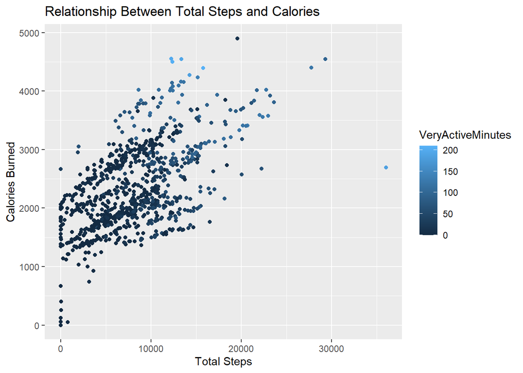

```r
ggplot(data = daily_activity) +
  geom_point(mapping=aes(x=TotalSteps, y=Calories, color= VeryActiveMinutes)) +
  labs(title = "Relationship Between Total Steps and Calories", x = "Total Steps", y = "Calories Burned")
```

**Relationship between Sedentary Minutes and Calories**

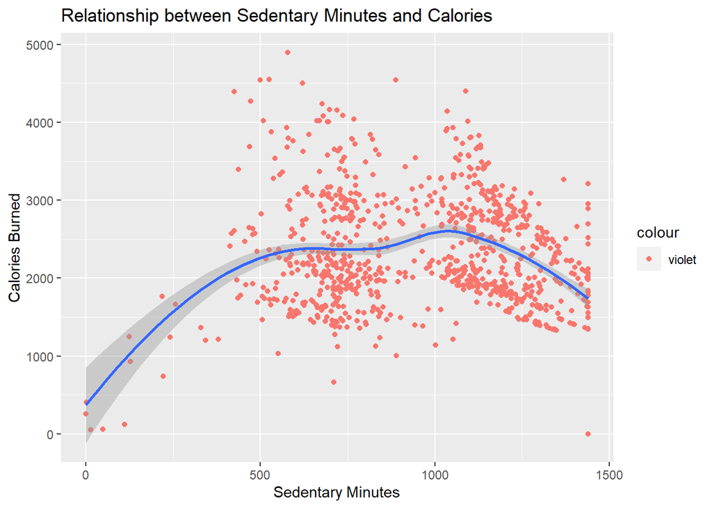

```r
ggplot(data = daily_activity)+
  geom_point(mapping = aes(x=SedentaryMinutes,y=Calories, color = "violet"))+
  geom_smooth(mapping = aes(x=SedentaryMinutes,y=Calories))+
  labs(title = "Relationship between Sedentary Minutes and Calories",x="Sedentary Minutes",y="Calories Burned")
```

**Relationship between Very active minutes and calories**

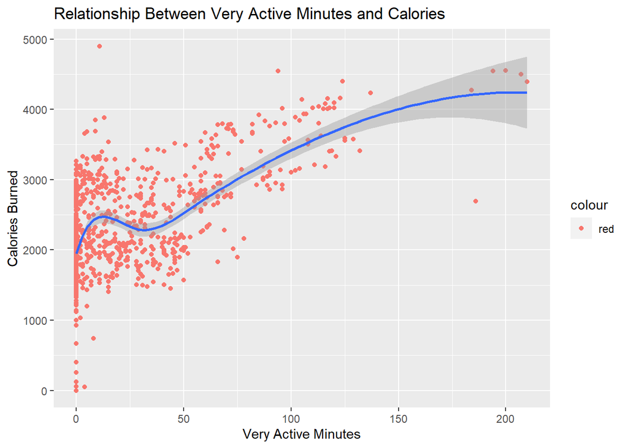

```r
ggplot(data = daily_activity) +
  geom_point(mapping = aes(x= VeryActiveMinutes, y = Calories, color = "red")) +
  geom_smooth(mapping=aes(x=VeryActiveMinutes, y=Calories)) +
  labs(title = "Relationship Between Very Active Minutes and Calories", x = "Very Active Minutes", y = "Calories Burned")
```

## Key Findings ##

**Users are not creating manual entries**

- Only 33 distinct user id’s in daily activity, 24 distinct in sleep log and 8 distinct in weight log.
- Therefore, Bellabeat should promote body positivity, so that users feel comfortable manually entering their weight.

**Not all users sleep with their fitbit**

- Only 24 users had sleep data. That’s why Bellbeat should promote the battery longevity and comfortness of the device.

**Active time**